# MT DEQ Modulair PM2.5 Model Development

Mason Dow

2025-03-30

# Load Data

```r
# Load data from data folder
lt_data <- read_excel("../data/LT_data.xlsx")
nc_data <- read_excel("../data/NC_data.xlsx")
rp_data <- read_excel("../data/RP_data.xlsx")
```

# Transform Data

## Calculate 24 hr. Averages

```r
## Calculate 24 hr. Averages
# uses averaging_threshold and daily_averages functions from function file
# applies 75% (18 hr.) threshold to hourly values to calculate daily averages

# Apply the function to each dataset:
rp_daily <- daily_averages(rp_data)
nc_daily <- daily_averages(nc_data)
lt_daily <- daily_averages(lt_data)
```

## Calculate Corresponding AQI Categories by site and PM2.5 parameter

```r
# Hourly Data

# Add AQI categories using AirMonitor's aqiCategories() function.
rp_data <- rp_data %>%
  mutate(rp_modulair_aqi = aqiCategories(rp_modulair_pm25, pollutant = "PM2.5", NAAQS = "PM2.5_2024"),
         rp_purpleair_aqi = aqiCategories(rp_purpleair_cf1, pollutant = "PM2.5", NAAQS = "PM2.5_2024"),
         rp_fem_aqi = aqiCategories(rp_fem_avg, pollutant = "PM2.5", NAAQS = "PM2.5_2024"))

nc_data <- nc_data %>%
  mutate(nc_modulair_aqi = aqiCategories(nc_modulair_pm25, pollutant = "PM2.5", NAAQS = "PM2.5_2024"),
         nc_purpleair_aqi = aqiCategories(nc_purpleair_cf1, pollutant = "PM2.5", NAAQS = "PM2.5_2024"),
         nc_fem_aqi = aqiCategories(nc_1020, pollutant = "PM2.5", NAAQS = "PM2.5_2024"))

lt_data <- lt_data %>%
  mutate(lt_modulair_aqi = aqiCategories(lt_modulair_pm25, pollutant = "PM2.5", NAAQS = "PM2.5_2024"),
         lt_purpleair_aqi = aqiCategories(lt_purpleair_cf1, pollutant = "PM2.5", NAAQS = "PM2.5_2024"),
         lt_fem_aqi = aqiCategories(lt_thermo, pollutant = "PM2.5", NAAQS = "PM2.5_2024"))
```

```r
# Daily Data

# Add AQI categories using AirMonitor's aqiCategories() function.
rp_daily <- rp_daily %>%
  mutate(rp_modulair_aqi = aqiCategories(rp_modulair_pm25, pollutant = "PM2.5", NAAQS = "PM2.5_2024"),
         rp_purpleair_aqi = aqiCategories(rp_purpleair_cf1, pollutant = "PM2.5", NAAQS = "PM2.5_2024"),
         rp_fem_aqi = aqiCategories(rp_fem_avg, pollutant = "PM2.5", NAAQS = "PM2.5_2024"))

nc_daily <- nc_daily %>%
  mutate(nc_modulair_aqi = aqiCategories(nc_modulair_pm25, pollutant = "PM2.5", NAAQS = "PM2.5_2024"),
         nc_purpleair_aqi = aqiCategories(nc_purpleair_cf1, pollutant = "PM2.5", NAAQS = "PM2.5_2024"),
         nc_fem_aqi = aqiCategories(nc_1020, pollutant = "PM2.5", NAAQS = "PM2.5_2024"))

lt_daily <- lt_daily %>%
  mutate(lt_modulair_aqi = aqiCategories(lt_modulair_pm25, pollutant = "PM2.5", NAAQS = "PM2.5_2024"),
         lt_purpleair_aqi = aqiCategories(lt_purpleair_cf1, pollutant = "PM2.5", NAAQS = "PM2.5_2024"),
         lt_fem_aqi = aqiCategories(lt_thermo, pollutant = "PM2.5", NAAQS = "PM2.5_2024"))
```

## Combine Data

```r
# Recode columns (& merge datasets, ignoring merge and using only RP dataset)
rp_modeling_data <- rp_data %>%
 rename(fem_avg = rp_fem_avg,
        mod_pm25 = rp_modulair_pm25,
        fem_aqi = rp_fem_aqi,
        mod_aqi = rp_modulair_aqi,
        mod_rh = rp_modulair_rh,
        mod_tempc = rp_modulair_tempc)

# #nc_combined <- nc_data %>%
#   rename(fem_avg = nc_1020,
#          mod_pm25 = nc_modulair_pm25,
#          fem_aqi = nc_fem_aqi,
#          mod_aqi = nc_modulair_aqi,
#          mod_rh = nc_modulair_rh)
#
# lt_combined <- lt_data %>%
#   rename(fem_avg = lt_thermo,
#          mod_pm25 = lt_modulair_pm25,
#          fem_aqi = lt_fem_aqi,
#          mod_aqi = lt_modulair_aqi,
#          mod_rh = lt_modulair_rh)

combined_modeling_data <- rp_modeling_data # only RP for now, other datasets not fit for model training/testing
```

# Model Development and Training via Tidymodels

## Split Data into Training/Testing

```r
data_split <- initial_split(combined_modeling_data, prop = 0.8)
training_data <- training(data_split)
testing_data  <- testing(data_split)
```

## Recipes

```r
# Recipe using only modulair PM2.5 (base recipe)
base_linear_recipe <- recipe(fem_avg ~ mod_pm25, data = training_data)

# Recipe with additive RH term
linear_rh_recipe <- recipe(fem_avg ~ mod_pm25 + mod_rh, data = training_data)

# Recipe with modulair PM2.5, RH, and temperature
linear_temp_rh_recipe <- recipe(fem_avg ~ mod_pm25 + mod_rh + mod_tempc, data = training_data)

# Recipe with interaction between modulair PM2.5 and RH
interaction_recipe <- recipe(fem_avg ~ mod_pm25 + mod_rh, data = training_data) %>%
  step_interact(terms = ~ mod_pm25:mod_rh)

# Recipe with full interactions among modulair PM2.5, RH, and temperature
full_interaction_recipe <- recipe(fem_avg ~ mod_pm25 + mod_rh + mod_tempc, data = training_data) %>%
  step_interact(terms = ~ mod_pm25:mod_rh + mod_pm25:mod_tempc + mod_rh:mod_tempc)

# Recipe adding a second-degree (quadratic) term for modulair PM2.5
quad_recipe <- recipe(fem_avg ~ mod_pm25, data = training_data) %>%
  step_poly(mod_pm25, degree = 2, options = list(raw = TRUE))
```

## Model Specifications

```r
# Not necessary for more than single spec as all specifications are linear, but can keep in code for future use/customization for other potential non-linear pollutant modeling

# Base linear regression model (using only mod_pm25)
linear_spec <- linear_reg() %>%
  set_engine("lm")

# Linear model with modulair PM2.5 and RH
linear_rh_spec <- linear_reg() %>%
  set_engine("lm")

# Linear model with modulair PM2.5, RH, and temperature
linear_temp_rh_spec <- linear_reg() %>%
  set_engine("lm")

# Model for interaction (will be paired with the interaction_recipe)
interaction_spec <- linear_reg() %>%
  set_engine("lm")

# Quadratic model specification (to be used with quad_recipe)
quad_spec <- linear_reg() %>%
  set_engine("lm")
```

## Workflows

```r
# Workflow for base linear model
wf_linear <- workflow() %>%
  add_model(linear_spec) %>%
  add_recipe(base_linear_recipe)

# Workflow for "Linear + RH" model
wf_linear_rh <- workflow() %>%
  add_model(linear_rh_spec) %>%
  add_recipe(linear_rh_recipe)

# Workflow for "Linear + RH + Temperature" model
wf_linear_temp_rh <- workflow() %>%
  add_model(linear_temp_rh_spec) %>%
  add_recipe(linear_temp_rh_recipe)

# Workflow for interaction model (mod_pm25 and mod_rh interaction)
wf_interaction <- workflow() %>%
  add_model(interaction_spec) %>%
  add_recipe(interaction_recipe)

# Workflow for full interaction model
wf_full_interaction <- workflow() %>%
  add_model(interaction_spec) %>%
  add_recipe(full_interaction_recipe)

# Workflow for quadratic model
wf_quad <- workflow() %>%
  add_model(quad_spec) %>%
  add_recipe(quad_recipe)
```

```r
# Define WF list:

wf_list <- list(
  "Base Linear"           = wf_linear,
  "Linear + RH"           = wf_linear_rh,
  "Linear + RH + Temp"    = wf_linear_temp_rh,
  "Interaction"           = wf_interaction,
  "Full Interaction"      = wf_full_interaction,
  "Quadratic"             = wf_quad
)
```

## Model Training

```r
# Model Fitting, Predictions and Metrics by Workflow
# For Loop using fit_evaluate_wf function from function file
# Loops over the workflows to fit models, predict on the test set, and collect metrics.

modeling_results <- map2(wf_list, names(wf_list), ~ fit_evaluate_wf(.x, .y, training_data, testing_data))

# Combine performance metrics from all models into a single table
all_modeling_metrics <- map_dfr(modeling_results, "metrics")
```

## Append Predictions to Testing Dataset

```r
# Append modeled predictions to the testing dataset
# Update the testing set with predictions from each model w/ new column for each model's prediction

# For each workflow, add a new column to the testing_data
testing_data_updated <- testing_data
for(model_name in names(wf_list)) {
  # Fit the workflow on the training data first
  fit_mod <- wf_list[[model_name]] %>% fit(data = training_data)
  # Generate predictions and add as a new column named "pred_<model_name>"
  col_name <- paste0("pred_", gsub(" ", "_", tolower(model_name)))
  testing_data_updated <- append_predictions(fit_mod, testing_data_updated, col_name)
}
```

### Adding Predictions of EPA PurpleAir U.S-wide Correction-Equation-Applied to Modulair Data

```r
# Apply the EPA PurpleAir U.S. correction equation to the Modulair measurements, AQI
testing_data_updated <- testing_data_updated %>%
  mutate(
    pa_us_correction = 0.524 * mod_pm25 - 0.0862 * mod_rh + 5.75
  )
```

## Define Predictions Columns & Corresponding AQI Category Columns

```r
# Define the names of the prediction columns in the updated testing data
prediction_cols <- c("pred_base_linear",
                     "pred_linear_+_rh",
                     "pred_linear_+_rh_+_temp",
                     "pred_interaction",
                     "pred_full_interaction",
                     "pred_quadratic",
                     "pa_us_correction")

# Define the corresponding predicted AQI column names
pred_aqi_cols <- paste0(prediction_cols, "_aqi")
```

## Add Corresponding Predicted AQI Categories to Testing Dataset

```r
# Build predicted AQI category columns for each prediction column
testing_data_updated <- testing_data_updated %>%
  mutate(across(all_of(prediction_cols),
                ~ aqiCategories(.x, pollutant = "PM2.5", NAAQS = "PM2.5_2024"),
                .names = "{.col}_aqi"))
```

# Model Evaluations

## Key Model Performance Metrics

```r
# Comparison table of performance metrics (rounded + formatted)

all_modeling_metrics %>%
  mutate(across(where(is.numeric), ~ round(.x, 2))) %>%
  kable(caption = "Key Accuracy Metrics by Model (Testing Data")
```

Key Accuracy Metrics by Model (Testing Data

| .metric | .estimator | .estimate | model |
| --- | --- | --- | --- |
| rmse | standard | 5.53 | Base Linear |
| rsq | standard | 0.57 | Base Linear |
| mae | standard | 3.45 | Base Linear |
| rmse | standard | 5.50 | Linear + RH |
| rsq | standard | 0.57 | Linear + RH |
| mae | standard | 3.42 | Linear + RH |
| rmse | standard | 5.52 | Linear + RH + Temp |
| rsq | standard | 0.57 | Linear + RH + Temp |
| mae | standard | 3.42 | Linear + RH + Temp |
| rmse | standard | 5.60 | Interaction |
| rsq | standard | 0.56 | Interaction |
| mae | standard | 3.38 | Interaction |
| rmse | standard | 5.28 | Full Interaction |
| rsq | standard | 0.61 | Full Interaction |
| mae | standard | 3.31 | Full Interaction |
| rmse | standard | 5.47 | Quadratic |
| rsq | standard | 0.58 | Quadratic |
| mae | standard | 3.39 | Quadratic |

## Residuals Plots

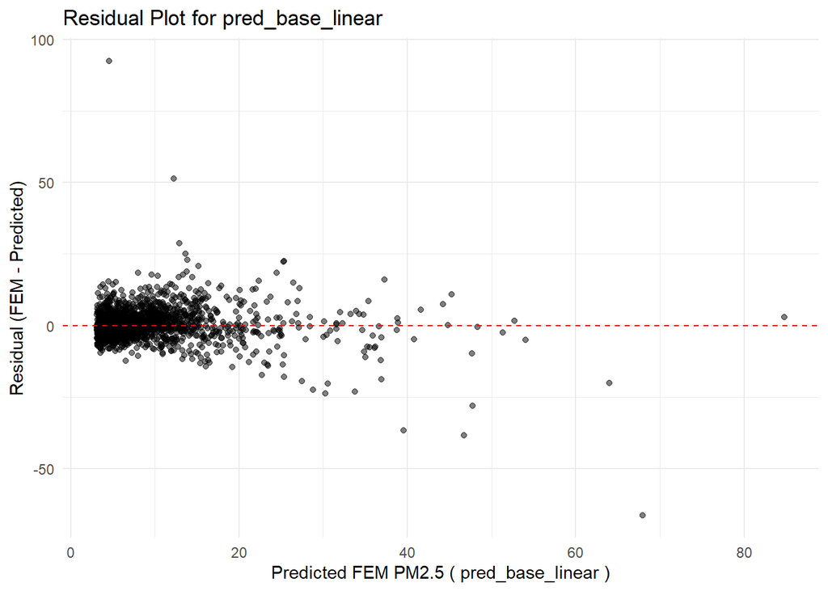

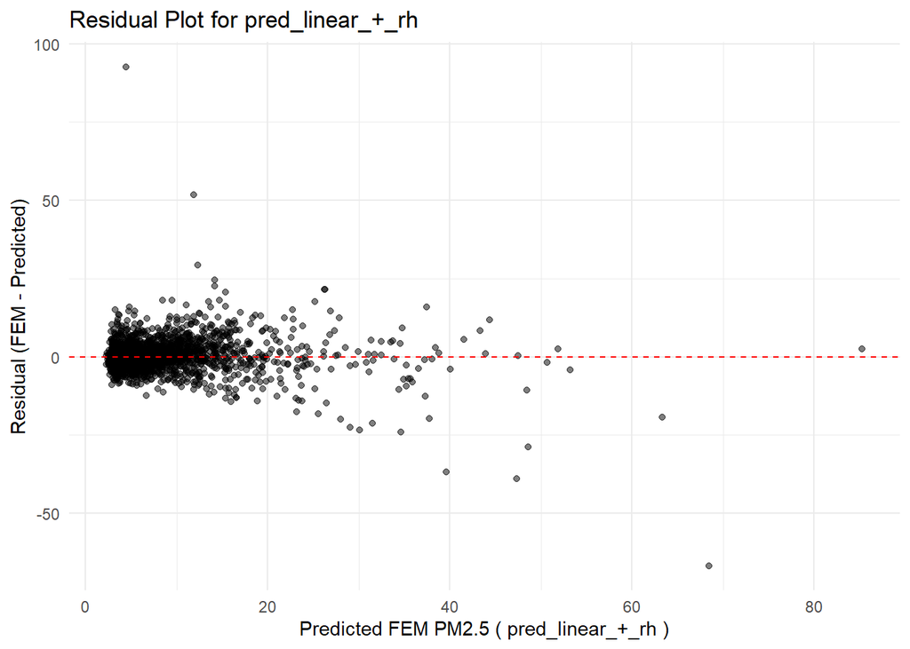

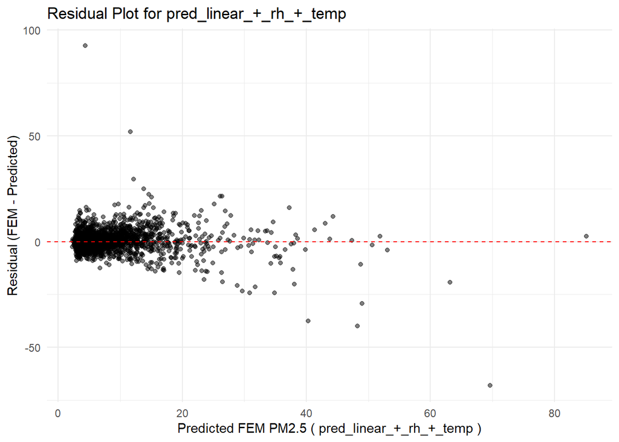

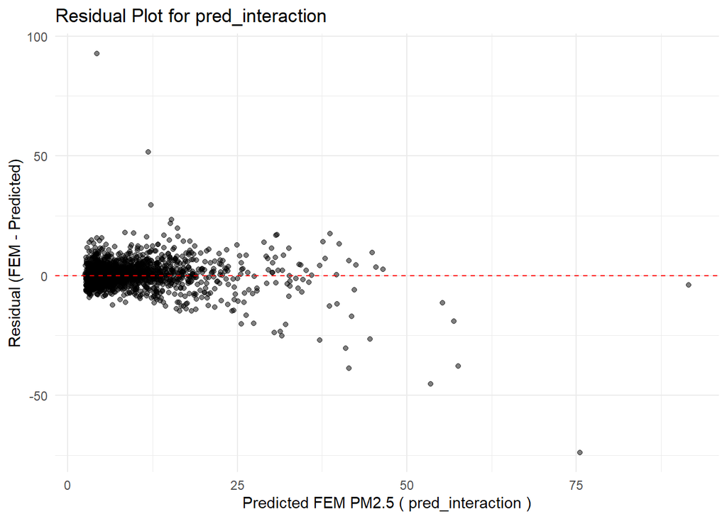

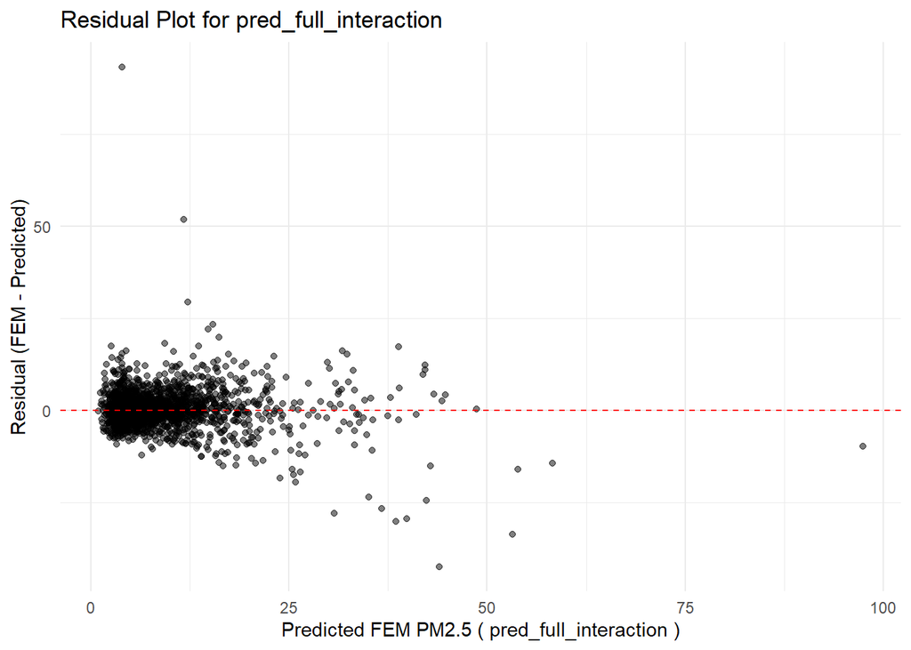

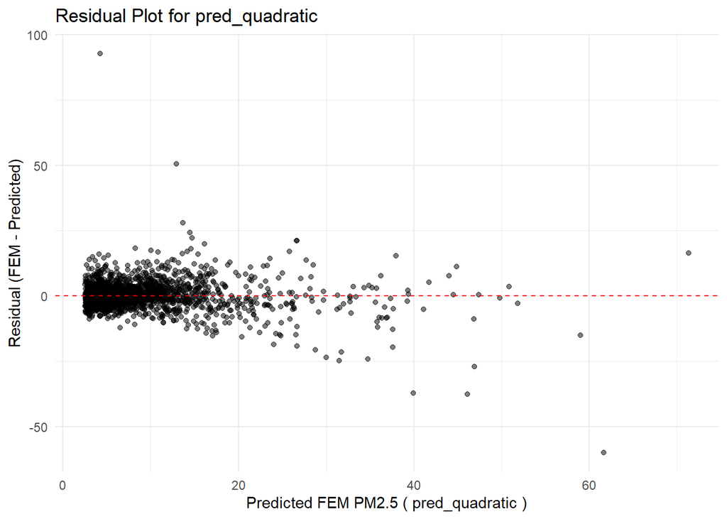

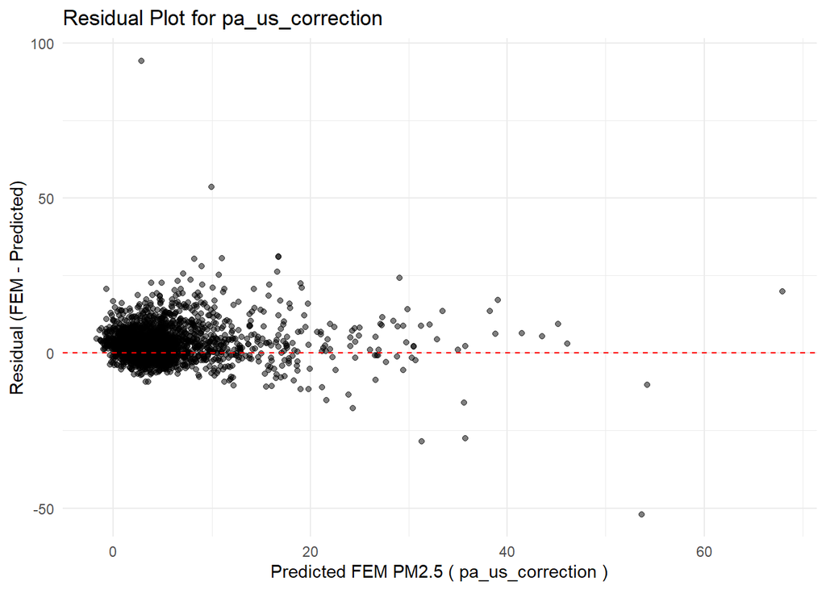

```r
# Generate residual plots for each prediction column
residual_plots <- map(prediction_cols, function(pred_col) {
  testing_data_updated %>%
    mutate(residual = fem_avg - .data[[pred_col]]) %>%
    ggplot(aes(x = .data[[pred_col]], y = residual)) +
      geom_point(alpha = 0.5) +
      geom_hline(yintercept = 0, linetype = "dashed", color = "red") +
      labs(title = paste("Residual Plot for", pred_col),
           x = paste("Predicted FEM PM2.5 (", pred_col, ")"),
           y = "Residual (FEM - Predicted)") +
      theme_minimal()
})

# Name each plot for easier reference
names(residual_plots) <- prediction_cols

# Print each residual plot
walk(residual_plots, print)
```

## Calculate Stratified Metrics

```r
# Loop over each pair of prediction and predicted AQI columns and calculate metrics using your calculate_all_metrics function
metrics_by_model <- map2(prediction_cols, pred_aqi_cols, function(pred_col, pred_aqi_col) {
  calculate_all_metrics(
    data = testing_data_updated,
    fem_col = "fem_avg",
    mod_col = pred_col,
    fem_aqi_col = "fem_aqi",
    mod_aqi_col = pred_aqi_col
  )
})

# Extract overall metrics into a single tibble and add a column for the model name
overall_metrics <- map_dfr(metrics_by_model, "overall") %>%
  mutate(model = prediction_cols)

# Extract stratified (by FEM AQI category) metrics into a single tibble
stratified_metrics <- map2_dfr(metrics_by_model, prediction_cols, function(x, model_name) {
  x$stratified %>% mutate(model = model_name)
})

# Print the overall performance metrics table
overall_metrics %>%
  knitr::kable(caption = "Overall Performance Metrics by Model")
```

Overall Performance Metrics by Model

| R_squared | Average_Error | MAE | RMSE | NRMSE | Slope | Intercept | aqi_match_frequency | model |
| --- | --- | --- | --- | --- | --- | --- | --- | --- |
| 0.5705881 | 0.0472430 | 3.447510 | 5.526534 | 65.96841 | 0.6112135 | 3.209834 | 0.8364611 | pred_base_linear |
| 0.5747094 | 0.0465801 | 3.424495 | 5.502876 | 65.68600 | 0.6183969 | 3.150318 | 0.8310992 | pred_linear_+_rh |
| 0.5721653 | 0.0439726 | 3.421293 | 5.522055 | 65.91494 | 0.6186309 | 3.150965 | 0.8337802 | pred_linear_+*rh*+_temp |
| 0.5645136 | -0.0130132 | 3.376573 | 5.604256 | 66.89615 | 0.6361592 | 3.061106 | 0.8310992 | pred_interaction |
| 0.6083007 | 0.0164041 | 3.310693 | 5.279464 | 63.01922 | 0.6498709 | 2.916819 | 0.8364611 | pred_full_interaction |
| 0.5829623 | 0.0156042 | 3.394391 | 5.467258 | 65.26084 | 0.6424495 | 2.979792 | 0.8328865 | pred_quadratic |
| 0.4876071 | 2.9897498 | 4.551044 | 6.718427 | 80.19563 | 0.4892905 | 1.288743 | 0.7484361 | pa_us_correction |

```r
# Print the stratified performance metrics table
stratified_metrics %>%
  knitr::kable(caption = "Performance Metrics Stratified by AQI Category and Model")
```

Performance Metrics Stratified by AQI Category and Model

| category | Count | R_squared | MAE | Average_Error | RMSE | NRMSE | model |
| --- | --- | --- | --- | --- | --- | --- | --- |
| 1 | 1481 | 0.0863047 | 2.590208 | -1.7179145 | 4.078035 | 102.57914 | pred_base_linear |
| 2 | 730 | 0.4054481 | 4.692113 | 3.0803072 | 6.086153 | 39.43191 | pred_base_linear |
| 3 | 32 | 0.2131669 | 10.063054 | 7.2840933 | 13.160747 | 31.18737 | pred_base_linear |
| 4 | 4 | 0.0001031 | 39.395738 | 39.3957381 | 53.179230 | 69.85777 | pred_base_linear |
| 1 | 1481 | 0.0864752 | 2.637835 | -1.6579340 | 4.133885 | 103.98401 | pred_linear_+_rh |
| 2 | 730 | 0.4165670 | 4.525364 | 2.9496834 | 5.948822 | 38.54215 | pred_linear_+_rh |
| 3 | 32 | 0.2149887 | 10.027995 | 7.4206646 | 12.982250 | 30.76438 | pred_linear_+_rh |
| 4 | 4 | 0.0004585 | 39.650660 | 39.6506600 | 53.401214 | 70.14938 | pred_linear_+_rh |
| 1 | 1481 | 0.0846953 | 2.638414 | -1.6589153 | 4.174120 | 104.99607 | pred_linear_+*rh*+_temp |
| 2 | 730 | 0.4191551 | 4.510296 | 2.9394422 | 5.938311 | 38.47405 | pred_linear_+*rh*+_temp |
| 3 | 32 | 0.2128262 | 10.105310 | 7.5014164 | 13.028650 | 30.87434 | pred_linear_+*rh*+_temp |
| 4 | 4 | 0.0005238 | 39.773536 | 39.7735355 | 53.479157 | 70.25177 | pred_linear_+*rh*+_temp |
| 1 | 1481 | 0.0839603 | 2.584324 | -1.5827036 | 4.287032 | 107.83627 | pred_interaction |
| 2 | 730 | 0.4034525 | 4.467725 | 2.5918356 | 6.051117 | 39.20491 | pred_interaction |
| 3 | 32 | 0.1630483 | 10.230446 | 7.9591215 | 12.411892 | 29.41279 | pred_interaction |
| 4 | 4 | 0.0101018 | 41.428914 | 39.5147242 | 53.841973 | 70.72837 | pred_interaction |
| 1 | 1481 | 0.1265805 | 2.537951 | -1.4890322 | 3.699298 | 93.05238 | pred_full_interaction |
| 2 | 730 | 0.4104102 | 4.377329 | 2.5247560 | 5.957217 | 38.59654 | pred_full_interaction |
| 3 | 32 | 0.1974158 | 9.623833 | 7.4029666 | 11.977780 | 28.38407 | pred_full_interaction |
| 4 | 4 | 0.0136599 | 42.972945 | 38.1537069 | 54.220520 | 71.22564 | pred_full_interaction |
| 1 | 1481 | 0.1023511 | 2.544218 | -1.5081574 | 4.043283 | 101.70499 | pred_quadratic |
| 2 | 730 | 0.4084582 | 4.639406 | 2.5534948 | 6.020815 | 39.00859 | pred_quadratic |
| 3 | 32 | 0.2061674 | 9.244582 | 6.9961988 | 12.266612 | 29.06852 | pred_quadratic |
| 4 | 4 | 0.0063286 | 42.765513 | 42.7655135 | 53.790358 | 70.66057 | pred_quadratic |
| 1 | 1481 | 0.0520051 | 2.713756 | 0.6058445 | 3.728611 | 93.78971 | pa_us_correction |
| 2 | 730 | 0.3186294 | 7.586421 | 7.0806788 | 8.944306 | 57.94975 | pa_us_correction |
| 3 | 32 | 0.2019013 | 14.771840 | 14.1300194 | 17.484138 | 41.43263 | pa_us_correction |
| 4 | 4 | 0.0011046 | 46.168865 | 46.1688652 | 55.758535 | 73.24602 | pa_us_correction |

## Data Visualizations

### 1:1 and Lines of Best Fit by Model

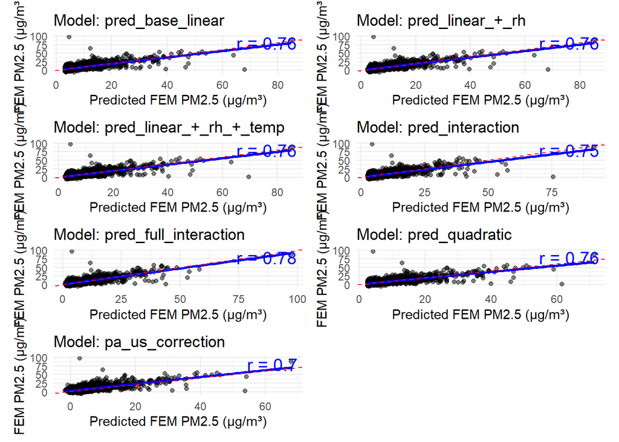

```r
# Generate scatterplots of Modeled vs. Actual FEM Avg. w/ 1:1 line + line of best fit (Pearson)
# uses plot_model_fit function from function file

# Loop over each prediction column and generate the plot using testing_data_updated
plots_list <- lapply(prediction_cols, function(pred_col) {
  plot_model_fit(test_data = testing_data_updated, pred_col = pred_col, fem_col = "fem_avg")
})

# Combine all plots in a grid
combined_model_fit_plots <- wrap_plots(plots_list, ncol = 2)
combined_model_fit_plots
```

# Final Model

## Modeling Conclusions and Model Selection Rationale

Below is a high-level analytical perspective on the RP site’s data and our modeling analysis comparing candidate correction models for the Modulair sensor’s PM2.5 measurements (using the RP FEM average as the target). Our gold standard reference is the Barkjohn et al. (2021) study on a nationwide PurpleAir correction factor. This discussion focuses on the model performance metrics and the trade-offs between model complexity and accuracy, which have guided my decision for further application.

### Key Accuracy Metrics (Testing Data)

- **Base Linear Model:**
  - RMSE: 5.53, R²: 0.57, MAE: 3.45
  - This model serves as a baseline.
- **Linear + RH Model:**
  - RMSE: 5.50, R²: 0.57, MAE: 3.42
  - Adding an additive relative humidity (RH) term slightly improves performance over the base linear model. The reduction in MAE and RMSE suggests that RH accounts for some of the sensor’s humidity‐related scattering issues.
- **Linear + RH + Temp Model:**
  - RMSE: 5.52, R²: 0.57, MAE: 3.42
  - Incorporating an additive temperature term did not yield further improvements over the Linear + RH model.
- **Interaction Models (Simple and Full):**
  - Although the Full Interaction model achieved a slightly lower RMSE (5.28) and higher R² (0.61), it comes with increased complexity. The additional interaction terms (e.g., between PM2.5 and RH) offer marginal gains in accuracy at the cost of interpretability and ease of deployment.
- **Quadratic Model:**
  - RMSE: 5.47, R²: 0.58, MAE: 3.39
  - This model shows intermediate performance but does not clearly outperform the simpler models.

### Overall Performance Comparison

| Model | R² | MAE | RMSE | Slope | Intercept | AQI Match Frequency |
| --- | --- | --- | --- | --- | --- | --- |
| Base Linear | 0.571 | 3.45 | 5.53 | 0.611 | 3.210 | 83.65% |
| **Linear + RH** | **0.575** | **3.42** | **5.50** | **0.618** | **3.150** | **83.11%** |
| Linear + RH + Temp | 0.572 | 3.42 | 5.52 | 0.619 | 3.151 | 83.38% |
| Interaction | 0.565 | 3.38 | 5.60 | 0.636 | 3.061 | 83.11% |
| Full Interaction | 0.608 | 3.31 | 5.28 | 0.650 | 2.917 | 83.65% |
| Quadratic | 0.583 | 3.39 | 5.47 | 0.642 | 2.980 | 83.29% |

### Synthesis and Decision

While the Full Interaction model slightly outperforms on some metrics, I have chosen the **Linear + RH model** for the following reasons:

1. **Simplicity and Interpretability:**  
   The Linear + RH model is straightforward and easier to implement and explain. It only requires two predictors—the raw sensor PM2.5 and the relative humidity—which are readily available from all sensors.
2. **Marginal Gains vs. Complexity:**  
   The additional complexity of the Full Interaction model results in only marginal improvements (e.g., a decrease in RMSE from 5.50 to 5.28 and MAE from 3.42 to 3.31) which may not justify the increased computational burden and potential for overfitting.
3. **Consistency Across AQI Categories:**  
   The Linear + RH model provides robust performance across AQI categories, with improved error metrics in the “Moderate” and “USG” ranges, and is competitive in the highest categories despite fewer observations.
4. **Alignment with Previous Work:**  
   This approach is consistent with the methodology outlined in Barkjohn et al. (2021), where a simple additive RH term significantly reduced bias and improved model accuracy across diverse conditions.

### Conclusion

Based on the above analysis, I will proceed with the **Linear + RH model** for correcting Modulair PM2.5 measurements using the RP FEM average as the reference. This model strikes an optimal balance between accuracy and simplicity, ensuring robust performance while minimizing overfitting and operational complexity.

*Note: These conclusions are drawn from the RP site data. Although I evaluated data from the NC and LT sites, issues with the NC site (likely due to under-sampling by the FEM BAM in Q1 2025), lack of higher concentrations at the LT site, and the stronger data completeness at the RP site have led me to focus on the RP data for this modeling effort. Future work will extend analysis, modeling and validation to these sites and other additional collocation sites.*

## Full Model Fitting and Predictions

### Applying Linear Model (and EPA US PA Correction Equation) to Entire Dataset

```r
# Fit the final "Linear + RH" model to the entire combined dataset
final_model <- wf_linear_rh %>%
  fit(data = combined_modeling_data)

# Generate final predictions using the final model on the combined dataset
final_predictions <- final_model %>%
  predict(new_data = combined_modeling_data)

# Combine the final predictions with the combined_modeling_data
# Rename the prediction column to "pred_linear_rh_final"
final_modeled_data <- combined_modeling_data %>%
  bind_cols(final_predictions %>% rename(pred_linear_rh_final = .pred)) %>%
  # Add a new column for the predicted AQI category based on the final predictions
  mutate(pred_linear_rh_final_aqi = aqiCategories(pred_linear_rh_final, pollutant = "PM2.5", NAAQS = "PM2.5_2024"))

# Apply the EPA PurpleAir U.S. correction equation to the Modulair measurements
final_modeled_data <- final_modeled_data %>%
  mutate(
    pa_us_correction = 0.524 * mod_pm25 - 0.0862 * mod_rh + 5.75,
    pa_corrected_mod_aqi = aqiCategories(pa_us_correction, pollutant = "PM2.5", NAAQS = "PM2.5_2024")
  )

# View the first few rows of the final modeled data
head(final_modeled_data)
```

```
## # A tibble: 6 × 19
##   siteid datetime            siteid_datetime   rp_1020 rp_1022 rp_thermo fem_avg
##   <chr>  <dttm>              <chr>               <dbl>   <dbl>     <dbl>   <dbl>
## 1 RP     2023-11-17 00:00:00 RP_2023-11-17 00…     2.2      NA       5.7    3.95
## 2 RP     2023-11-17 01:00:00 RP_2023-11-17 01…     5.1      NA       4.5    4.8
## 3 RP     2023-11-17 02:00:00 RP_2023-11-17 02…     9.4      NA      14.2   11.8
## 4 RP     2023-11-17 03:00:00 RP_2023-11-17 03…     2.5      NA       7.7    5.1
## 5 RP     2023-11-17 04:00:00 RP_2023-11-17 04…     2.6      NA      -0.2    1.2
## 6 RP     2023-11-17 05:00:00 RP_2023-11-17 05…     6.1      NA       5      5.55
## # ℹ 12 more variables: rp_fem_weighted_avg <dbl>, mod_pm25 <dbl>, mod_rh <dbl>,
## #   mod_tempc <dbl>, rp_purpleair_cf1 <dbl>, mod_aqi <int>,
## #   rp_purpleair_aqi <int>, fem_aqi <int>, pred_linear_rh_final <dbl>,
## #   pred_linear_rh_final_aqi <int>, pa_us_correction <dbl>,
## #   pa_corrected_mod_aqi <int>
```

### Assess Final Model Prediction Accuracy

```r
# Compute performance metrics for our Final Model (Linear + RH)
final_model_metrics <- calculate_all_metrics(
  data = final_modeled_data,
  fem_col = "fem_avg",
  mod_col = "pred_linear_rh_final",
  fem_aqi_col = "fem_aqi",
  mod_aqi_col = "pred_linear_rh_final_aqi"
)
final_overall <- final_model_metrics$overall %>%
  mutate(Model = "Final Modeled PM2.5 (Linear + RH)")

# Compute performance metrics for the Uncorrected Modulair PM2.5 data
uncorrected_metrics <- calculate_all_metrics(
  data = final_modeled_data,
  fem_col = "fem_avg",
  mod_col = "mod_pm25",
  fem_aqi_col = "fem_aqi",
  mod_aqi_col = "mod_aqi"
)
uncorrected_overall <- uncorrected_metrics$overall %>%
  mutate(Model = "Uncorrected Modulair PM2.5")

# Compute performance metrics for the PA US Correction applied to Modulair data
pa_us_metrics <- calculate_all_metrics(
  data = final_modeled_data,
  fem_col = "fem_avg",
  mod_col = "pa_us_correction",
  fem_aqi_col = "fem_aqi",
  mod_aqi_col = "pa_corrected_mod_aqi"
)
pa_us_overall <- pa_us_metrics$overall %>%
  mutate(Model = "EPA PA US Correction Applied")

# Combine all metrics into a single comparison table
comparison_table <- bind_rows(final_overall, uncorrected_overall, pa_us_overall) %>%
  select(Model, R_squared, Average_Error, MAE, RMSE, NRMSE, Slope, Intercept, aqi_match_frequency)

# Display the final comparison table
comparison_table %>%
  knitr::kable(caption = "Overall Performance Metrics Comparison: Final Model vs. Uncorrected Modulair vs. PA US Correction")
```

Overall Performance Metrics Comparison: Final Model vs. Uncorrected Modulair vs. PA US Correction

| Model | R_squared | Average_Error | MAE | RMSE | NRMSE | Slope | Intercept | aqi_match_frequency |
| --- | --- | --- | --- | --- | --- | --- | --- | --- |
| Final Modeled PM2.5 (Linear + RH) | 0.6737858 | 0.0000000 | 3.297588 | 4.873838 | 58.96469 | 0.6737858 | 2.6963853 | 0.8408460 |
| Uncorrected Modulair PM2.5 | 0.6693856 | 0.1671611 | 3.833668 | 6.360686 | 76.95288 | 1.0571365 | -0.6394333 | 0.8240882 |
| EPA PA US Correction Applied | 0.5821592 | 2.9382631 | 4.399631 | 6.259130 | 75.72425 | 0.5515804 | 0.7682338 | 0.7665561 |

## Coefficients and Equation

```r
# Extract the underlying model object using extract_fit_parsnip()
final_linear_rh_model_fit <- extract_fit_parsnip(final_model)$fit

# Get the coefficients from the linear model
linear_rh_model_coefs <- coef(final_linear_rh_model_fit)
print(linear_rh_model_coefs)
```

```
## (Intercept)    mod_pm25      mod_rh
##  1.64551584  0.63666855  0.02704661
```

```r
# Create readable equation using the correct coefficient names
model_equation <- paste0("Corrected PM2.5 = ",
                         round(linear_rh_model_coefs["(Intercept)"], 2), " + ",
                         round(linear_rh_model_coefs["mod_pm25"], 2), " * Modulair PM2.5 + ",
                         round(linear_rh_model_coefs["mod_rh"], 2), " * Modulair rh")
cat("Linear Model Equation:\n", model_equation, "\n")
```

```
## Linear Model Equation:
##  Corrected PM2.5 = 1.65 + 0.64 * Modulair PM2.5 + 0.03 * Modulair rh
```